# Proj2_Presentation

Ruofeng Tang

2023-10-11

## Introduction

Our group decided to use linear regression models, in order to predict body fat percentage based on several measurements. After cleaning data rows that are most likely incorrect, we will explore 2 ways to simulate the modern American male population, as opposed to 1970 American male samples from given data set. Then, we will decide on which independent measurements we need for the regression model. In the end, we will use regression coefficients and prediction interval to tell our users what is the average body fat percentage given their measurements (Abdomen circumference), and what is the 95% prediction range.

## Data Cleaning

First, I cross-examined body fat percentage with density, and adiposity with height/weight. Based on given formulas, these measurements should align relatively well.

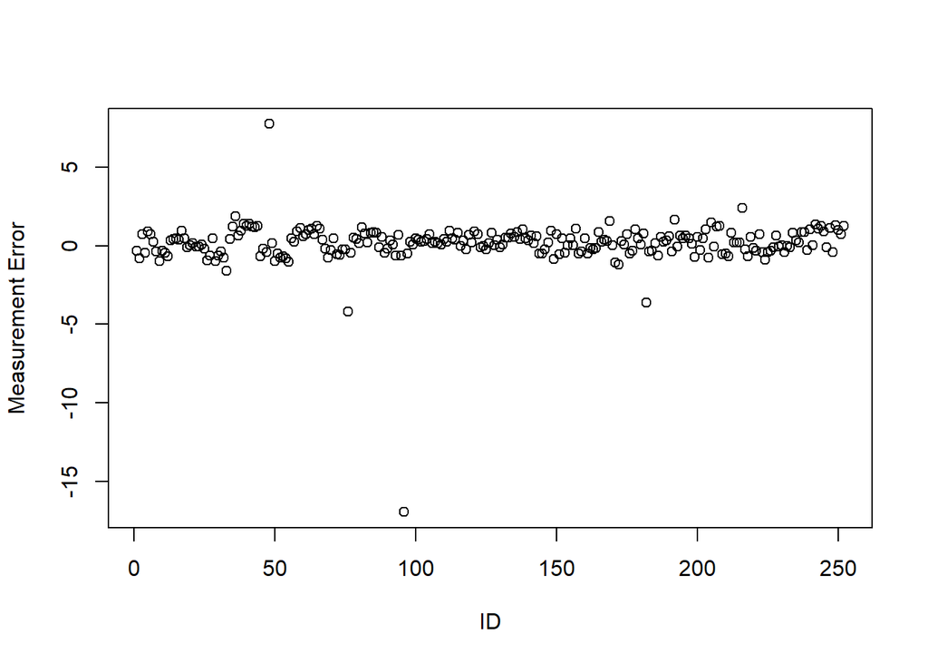

```r
# Need 'BodyFat.csv' in the same folder
df = read.csv('BodyFat.csv')

# from density and bodyfat relationship
diff1 = 495/df$DENSITY - 450 - df$BODYFAT

plot(diff1,xlab="ID",ylab="Measurement Error")
```

Judging from plot, set the error threshold to be |3| and |5|.

```r
# index 48, 96 maybe change
df[abs(diff1) > 5,]
```

```
##    IDNO BODYFAT DENSITY AGE WEIGHT HEIGHT ADIPOSITY NECK CHEST ABDOMEN   HIP
## 48   48     6.4  1.0665  39  148.5  71.25      20.6 34.6  89.8    79.5  92.7
## 96   96    17.3  1.0991  53  224.5  77.75      26.1 41.1 113.2    99.2 107.5
##    THIGH KNEE ANKLE BICEPS FOREARM WRIST
## 48  52.7 37.5  21.9   28.8    26.8  17.9
## 96  61.7 42.3  23.2   32.9    30.8  20.4
```

```r
# index 76,182 maybe change
df[abs(diff1) > 3,]
```

```
##     IDNO BODYFAT DENSITY AGE WEIGHT HEIGHT ADIPOSITY NECK CHEST ABDOMEN   HIP
## 48    48     6.4  1.0665  39 148.50  71.25      20.6 34.6  89.8    79.5  92.7
## 76    76    18.3  1.0666  61 148.25  67.50      22.9 36.0  91.6    81.8  94.8
## 96    96    17.3  1.0991  53 224.50  77.75      26.1 41.1 113.2    99.2 107.5
## 182  182     0.0  1.1089  40 118.50  68.00      18.1 33.8  79.3    69.4  85.0
##     THIGH KNEE ANKLE BICEPS FOREARM WRIST
## 48   52.7 37.5  21.9   28.8    26.8  17.9
## 76   54.5 37.0  21.4   29.3    27.0  18.3
## 96   61.7 42.3  23.2   32.9    30.8  20.4
## 182  47.2 33.5  20.2   27.7    24.6  16.5
```

Examine each row separately:

```r
df[48,] # cannot decide
```

```
##    IDNO BODYFAT DENSITY AGE WEIGHT HEIGHT ADIPOSITY NECK CHEST ABDOMEN  HIP
## 48   48     6.4  1.0665  39  148.5  71.25      20.6 34.6  89.8    79.5 92.7
##    THIGH KNEE ANKLE BICEPS FOREARM WRIST
## 48  52.7 37.5  21.9   28.8    26.8  17.9
```

```r
df[96,] # bmi indicates overweight, but body fat normal, circumferences normal. Not enough evidence to delete it.
```

```
##    IDNO BODYFAT DENSITY AGE WEIGHT HEIGHT ADIPOSITY NECK CHEST ABDOMEN   HIP
## 96   96    17.3  1.0991  53  224.5  77.75      26.1 41.1 113.2    99.2 107.5
##    THIGH KNEE ANKLE BICEPS FOREARM WRIST
## 96  61.7 42.3  23.2   32.9    30.8  20.4
```

```r
df[76,] # all normal, cannot decide
```

```
##    IDNO BODYFAT DENSITY AGE WEIGHT HEIGHT ADIPOSITY NECK CHEST ABDOMEN  HIP
## 76   76    18.3  1.0666  61 148.25   67.5      22.9   36  91.6    81.8 94.8
##    THIGH KNEE ANKLE BICEPS FOREARM WRIST
## 76  54.5   37  21.4   29.3      27  18.3
```

```r
df[182,] # body fat 0, try recover with density
```

```
##     IDNO BODYFAT DENSITY AGE WEIGHT HEIGHT ADIPOSITY NECK CHEST ABDOMEN HIP
## 182  182       0  1.1089  40  118.5     68      18.1 33.8  79.3    69.4  85
##     THIGH KNEE ANKLE BICEPS FOREARM WRIST
## 182  47.2 33.5  20.2   27.7    24.6  16.5
```

```r
temp = 495/df[182,3] - 450 # negative value -3.6, cannot use, should delete.
df = df[-182,]
```

In conclusion, Index 182 had body fat 0, and applying the formula cannot recover it. So it should be deleted later. Next, try the BMI, height and weight formula:

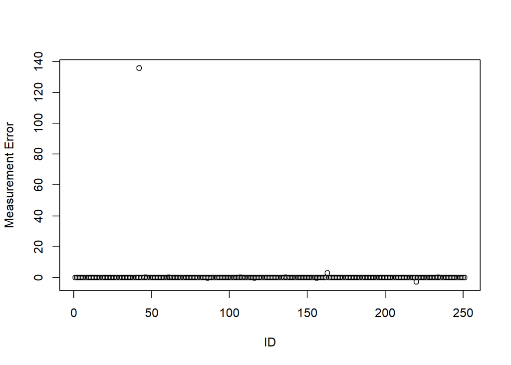

```r
# from BMI, height and weight
diff2 = 703 * df$WEIGHT / (df$HEIGHT^2) - df$ADIPOSITY
plot(diff2,xlab='ID',ylab='Measurement Error')
```

```r
# notice a significant outlier. Index 42 must be changed
df[abs(diff2) > 100,]
```

```
##    IDNO BODYFAT DENSITY AGE WEIGHT HEIGHT ADIPOSITY NECK CHEST ABDOMEN   HIP
## 42   42    31.7   1.025  44    205   29.5      29.9 36.6   106   104.3 115.5
##    THIGH KNEE ANKLE BICEPS FOREARM WRIST
## 42  70.6 42.5  23.7   33.6    28.7  17.4
```

```r
# observe that the height 29.5 is abnormal. Try recover it with weight and adiposity.
df[42,'HEIGHT'] = sqrt(df[42,'WEIGHT'] * 703 / df[42,'ADIPOSITY'])
df[42,'HEIGHT']
```

```
## [1] 69.4255
```

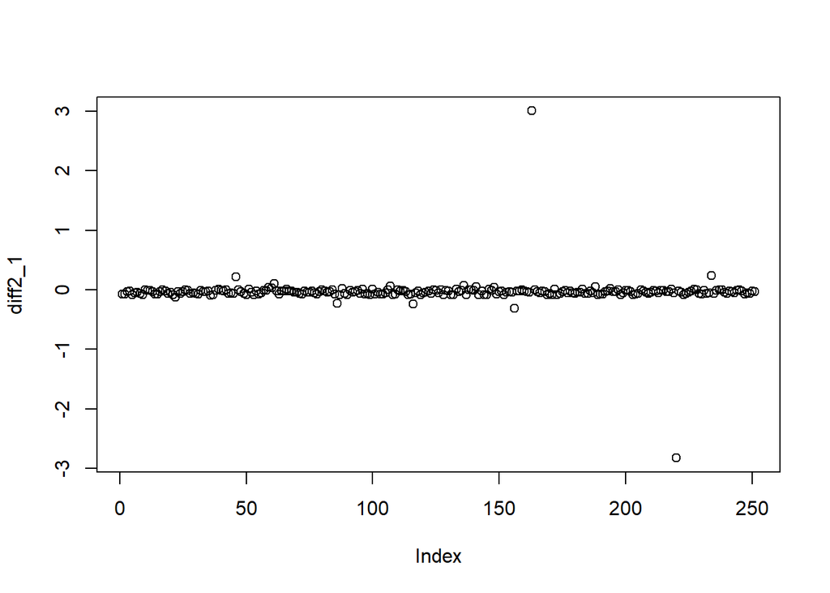

```r
diff2_1 = 703 * df$WEIGHT / (df$HEIGHT^2) - df$ADIPOSITY

plot(diff2_1)
```

From the plot, set the error threshold |2|:

```r
# index 162, 220 maybe change, but no obvious anomaly.
df[abs(diff2_1) > 2,]
```

```
##     IDNO BODYFAT DENSITY AGE WEIGHT HEIGHT ADIPOSITY NECK CHEST ABDOMEN   HIP
## 163  163    13.3  1.0690  33 184.25  68.75      24.4 40.7  98.9    92.1 103.5
## 221  221    12.7  1.0706  54 153.25  70.50      24.5 38.5  99.0    91.8  96.2
##     THIGH KNEE ANKLE BICEPS FOREARM WRIST
## 163  64.0 37.3  23.5   33.5    30.6  19.7
## 221  57.7 38.1  23.9   31.4    29.9  18.9
```

From both formulas, we determined abnormal values with index 182 and 42. Abnormal height of index 42 was changed, but the formula did not provide a reasonable alternative for abnormal body fat percentage of index 182. So, index 182 was deleted.

Next, try to check anomalies in individual columns:

```r
# index 172 has bodyfat 1.9, abnormal
df[df$BODYFAT==min(df$BODYFAT),]
```

```
##     IDNO BODYFAT DENSITY AGE WEIGHT HEIGHT ADIPOSITY NECK CHEST ABDOMEN  HIP
## 172  172     1.9  1.0983  35 125.75   65.5      20.6   34  90.8      75 89.2
##     THIGH KNEE ANKLE BICEPS FOREARM WRIST
## 172    50 34.8    22   24.8    25.9  16.9
```

Index 172 did not show up when detecting anomaly with body fat/density formula, suggesting that the density aligns with the abnormal body fat percentage. Therefore, it should be deleted.

```r
df = df[-172,]
```

## Distribution Matching (1970 distribution to Now)

The data set is from 1970s, decades ago. To accurately predict body fat percentage today, we want to somehow manipulate the age distribution to imitate modern American society.

For our modern age distribution data, we used [Resident population of the United States by sex and age as of July 1, 2022(in millions)](https://www.statista.com/statistics/241488/population-of-the-us-by-sex-and-age/)

This data set gave us the population of US males by 5-year age group (0-4, 5-9, ……, 80-84,85+).

We came up with 2 methods:

### a.Linear Regression with bootstrapping (restricted)

So, we tried to bootstrap each age group separately. To bootstrap each age group, we want the 1970 data set to have enough samples to reach the 2022 age distribution’s percentage.

```r
# Each entry corresponds to age group 0-4, 5-9, ......, 80-84,85+
samples1970 = c(0,0,0,0,10,26,17,21,60,33,26,21,15,12,8,0,1,0)
populations2022 = c(9.48, 10.23, 10.7, 11.08, 11.6, 11.35, 11.84, 11.3, 10.82, 9.84, 10.43, 10.37, 10.3, 8.97, 7.04, 4.91, 2.83, 2.28)

populations2022
```

```
##  [1]  9.48 10.23 10.70 11.08 11.60 11.35 11.84 11.30 10.82  9.84 10.43 10.37
## [13] 10.30  8.97  7.04  4.91  2.83  2.28
```

```r
# notice that in the first and last several age groups, there are no samples or only 1 sample
samples1970
```

```
##  [1]  0  0  0  0 10 26 17 21 60 33 26 21 15 12  8  0  1  0
```

Due to the lack of 1970 samples from age groups 0-19, 75+, we decided to ignore those age groups and focus on age groups in 20-74:

```r
df[df$AGE>74,]
```

```
##    IDNO BODYFAT DENSITY AGE WEIGHT HEIGHT ADIPOSITY NECK CHEST ABDOMEN  HIP
## 79   79    21.1  1.0498  81 161.25  70.25        23 37.8  96.4    95.4 99.3
##    THIGH KNEE ANKLE BICEPS FOREARM WRIST
## 79  53.5 37.5  21.5   31.4    26.8  18.3
```

```r
# remove the sample at age 81
df = df[-79,]

# new samples and populations by age group
pop1970 = c(10,26,17,21,60,33,26,21,15,12,8)
pop2022 = c(11.6, 11.35, 11.84, 11.3, 10.82, 9.84, 10.43, 10.37, 10.3, 8.97, 7.04)

# the 1970 and 2022 age distributions
dist1970 = pop1970 / sum(pop1970)
dist2022 = pop2022 / sum(pop2022)

dist1970
```

```
##  [1] 0.04016064 0.10441767 0.06827309 0.08433735 0.24096386 0.13253012
##  [7] 0.10441767 0.08433735 0.06024096 0.04819277 0.03212851
```

```r
dist2022
```

```
##  [1] 0.10187950 0.09968382 0.10398735 0.09924469 0.09502898 0.08642192
##  [7] 0.09160372 0.09107676 0.09046197 0.07878096 0.06183032
```

We hoped to get a new data set that follows the 2022 age distribution out of the 1970 data set. For 1970 age groups with percentages higher than 2022 distribution, we want to select fewer samples; for age groups with lower percentages, we want to select more samples. At the same time, we want to pick the maximum sample size such that we can pick enough people to satisfy 2022 percentage for each age group.

```r
size = length(df[,1])
cond = -1
while (min(cond) < 0) {
  cond = pop1970 - dist2022*size
  size = size - 1
}

# sample size
size
```

```
## [1] 97
```

```r
# how many samples from each age group in order to simulate 2022 age distribution
dist2022*size
```

```
##  [1]  9.882312  9.669331 10.086773  9.626735  9.217811  8.382926  8.885561
##  [8]  8.834446  8.774811  7.641753  5.997541
```

So, we need to pick 10,10,10,10,9,8,9,9,9,8,6 people from respective age groups. This smaller data set will simulate 2022 age distribution.

```r
set.seed(123)

# separate 1970 data set by age groups
df_mod = df
df24 = df_mod[df_mod$AGE<=24,]
df29 = df_mod[df_mod$AGE>24&df_mod$AGE<=29,]
df34 = df_mod[df_mod$AGE>29&df_mod$AGE<=34,]
df39 = df_mod[df_mod$AGE>34&df_mod$AGE<=39,]
df44 = df_mod[df_mod$AGE>39&df_mod$AGE<=44,]
df49 = df_mod[df_mod$AGE>44&df_mod$AGE<=49,]
df54 = df_mod[df_mod$AGE>49&df_mod$AGE<=54,]
df59 = df_mod[df_mod$AGE>54&df_mod$AGE<=59,]
df64 = df_mod[df_mod$AGE>59&df_mod$AGE<=64,]
df69 = df_mod[df_mod$AGE>64&df_mod$AGE<=69,]
df74 = df_mod[df_mod$AGE>69&df_mod$AGE<=74,]

# random selection process. Note that age group 24- has only 10 samples, no need to randomly select.
rd29 <- sample(1:length(df29[,1]), 10, replace = FALSE)
rd34 <- sample(1:length(df34[,1]), 10, replace = FALSE)
rd39 <- sample(1:length(df39[,1]), 10, replace = FALSE)
rd44 <- sample(1:length(df44[,1]), 9, replace = FALSE)
rd49 <- sample(1:length(df49[,1]), 8, replace = FALSE)
rd54 <- sample(1:length(df54[,1]), 9, replace = FALSE)
rd59 <- sample(1:length(df59[,1]), 9, replace = FALSE)
rd64 <- sample(1:length(df64[,1]), 9, replace = FALSE)
rd69 <- sample(1:length(df69[,1]), 8, replace = FALSE)
rd74 <- sample(1:length(df74[,1]), 6, replace = FALSE)

# new data set
df_sample = rbind(df24,df29[rd29,],df34[rd34,],df39[rd39,],df44[rd44,],df49[rd49,],df54[rd54,],df59[rd59,],df64[rd64,],df69[rd69,],df74[rd74,])
head(df_sample)
```

```
##    IDNO BODYFAT DENSITY AGE WEIGHT HEIGHT ADIPOSITY NECK CHEST ABDOMEN   HIP
## 1     1    12.6  1.0708  23 154.25  67.75      23.7 36.2  93.1    85.2  94.5
## 2     2     6.9  1.0853  22 173.25  72.25      23.4 38.5  93.6    83.0  98.7
## 3     3    24.6  1.0414  22 154.00  66.25      24.7 34.0  95.8    87.9  99.2
## 5     5    27.8  1.0340  24 184.25  71.25      25.6 34.4  97.3   100.0 101.9
## 6     6    20.6  1.0502  24 210.25  74.75      26.5 39.0 104.5    94.4 107.8
## 10   10    12.0  1.0722  23 198.25  73.50      25.8 42.1  99.6    88.6 104.1
##    THIGH KNEE ANKLE BICEPS FOREARM WRIST
## 1   59.0 37.3  21.9   32.0    27.4  17.1
## 2   58.7 37.3  23.4   30.5    28.9  18.2
## 3   59.6 38.9  24.0   28.8    25.2  16.6
## 5   63.2 42.2  24.0   32.2    27.7  17.7
## 6   66.0 42.0  25.6   35.7    30.6  18.8
## 10  63.1 41.7  25.0   35.6    30.0  19.2
```

Although this new data set had 2022 age distribution, there was information loss because of the random selection process and the reduced sample size. To mitigate that, we sampled 4 more times and combined them to a larger data set. It risked repeating several data entries, but it was more beneficial by preventing information loss.

```r
# new data set above
df_sample_comb = df_sample

for (i in 1:4){
  rd29 <- sample(1:length(df29[,1]), 10, replace = FALSE)
  rd34 <- sample(1:length(df34[,1]), 10, replace = FALSE)
  rd39 <- sample(1:length(df39[,1]), 10, replace = FALSE)
  rd44 <- sample(1:length(df44[,1]), 9, replace = FALSE)
  rd49 <- sample(1:length(df49[,1]), 8, replace = FALSE)
  rd54 <- sample(1:length(df54[,1]), 9, replace = FALSE)
  rd59 <- sample(1:length(df59[,1]), 9, replace = FALSE)
  rd64 <- sample(1:length(df64[,1]), 9, replace = FALSE)
  rd69 <- sample(1:length(df69[,1]), 8, replace = FALSE)
  rd74 <- sample(1:length(df74[,1]), 6, replace = FALSE)
  df_temp = rbind(df24,df29[rd29,],df34[rd34,],df39[rd39,],
                  df44[rd44,],df49[rd49,],df54[rd54,],df59[rd59,],
                  df64[rd64,],df69[rd69,],df74[rd74,])
  df_sample_comb = rbind(df_sample_comb,df_temp)
}
```

For our linear regression model, we first checked one simulated data set with size 98, and then checked 5 sets combined with size 490.

```r
# remove index
df_sample = df_sample[,-1]

# remove density, effectively same as body fat
df_sample = df_sample[,-2]

# all parameters
model1 = lm(BODYFAT~.,data=df_sample)
summary(model1)  #0.77
```

```
##
## Call:
## lm(formula = BODYFAT ~ ., data = df_sample)
##
## Residuals:
##     Min      1Q  Median      3Q     Max
## -9.3866 -2.7947 -0.1408  2.8892  8.6602
##
## Coefficients:
##              Estimate Std. Error t value Pr(>|t|)
## (Intercept)  8.946465  49.753569   0.180   0.8577
## AGE          0.008202   0.046652   0.176   0.8609
## WEIGHT      -0.004529   0.137530  -0.033   0.9738
## HEIGHT      -0.418836   0.665116  -0.630   0.5306
## ADIPOSITY   -0.286793   1.009063  -0.284   0.7770
## NECK        -0.844227   0.359109  -2.351   0.0211 *
## CHEST        0.026572   0.182847   0.145   0.8848
## ABDOMEN      0.869808   0.149734   5.809 1.12e-07 ***
## HIP         -0.369355   0.247756  -1.491   0.1398
## THIGH        0.218448   0.214913   1.016   0.3124
## KNEE         0.254347   0.377232   0.674   0.5020
## ANKLE        0.184584   0.243061   0.759   0.4498
## BICEPS       0.038459   0.255714   0.150   0.8808
## FOREARM      0.474219   0.304122   1.559   0.1227
## WRIST       -0.493265   0.770145  -0.640   0.5236
## ---
## Signif. codes:  0 '***' 0.001 '**' 0.01 '*' 0.05 '.' 0.1 ' ' 1
##
## Residual standard error: 4.075 on 83 degrees of freedom
## Multiple R-squared:  0.7704, Adjusted R-squared:  0.7317
## F-statistic:  19.9 on 14 and 83 DF,  p-value: < 2.2e-16
```

```r
# from previous model information, try abdomen only
model4 = lm(BODYFAT~ABDOMEN, data=df_sample)
summary(model4)  #0.67
```

```
##
## Call:
## lm(formula = BODYFAT ~ ABDOMEN, data = df_sample)
##
## Residuals:
##     Min      1Q  Median      3Q     Max
## -15.838  -3.167  -0.155   2.891   9.644
##
## Coefficients:
##              Estimate Std. Error t value Pr(>|t|)
## (Intercept) -32.71387    3.75298  -8.717 8.46e-14 ***
## ABDOMEN       0.55605    0.03996  13.914  < 2e-16 ***
## ---
## Signif. codes:  0 '***' 0.001 '**' 0.01 '*' 0.05 '.' 0.1 ' ' 1
##
## Residual standard error: 4.553 on 96 degrees of freedom
## Multiple R-squared:  0.6685, Adjusted R-squared:  0.665
## F-statistic: 193.6 on 1 and 96 DF,  p-value: < 2.2e-16
```

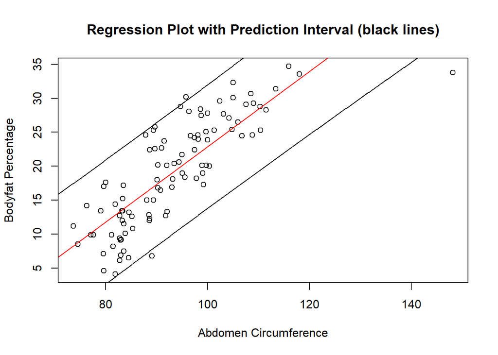

```r
plot(df_sample$ABDOMEN,df_sample$BODYFAT,xlab="Abdomen Circumference",ylab='Bodyfat Percentage',main='Regression Plot with Prediction Interval (black lines)')
abline(model4,col='red')

# create prediction interval
xrange = seq(60,150,0.1)    # checked data range and significant digits from 1970 data set
predicts_ab = matrix(0,nrow=3,ncol=length(xrange))

for (i in 1:length(xrange)){
  predicts_ab[,i] = predict(model4,
                            newdata=data.frame(ABDOMEN=xrange[i]),
                            interval='prediction')
}

lines(xrange,predicts_ab[2,])
lines(xrange,predicts_ab[3,])
```

```r
prediction_range = predicts_ab[3,1] - predicts_ab[2,1]

# prediction range is 18.91, meaning +/- 9.5
prediction_range
```

```
## [1] 18.91686
```

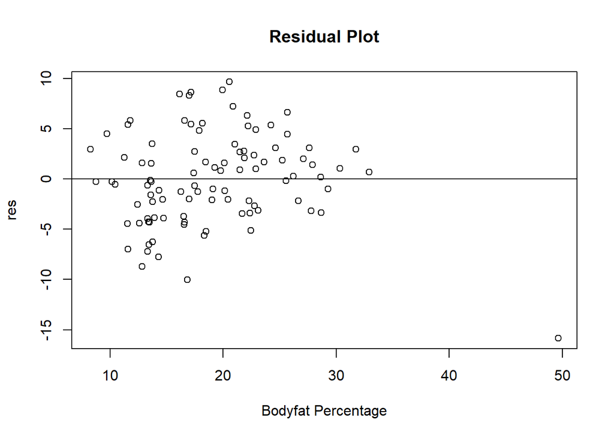

```r
res <- resid(model4)
plot(fitted(model4), res,main='Residual Plot',xlab='Bodyfat Percentage')
abline(0,0)
```

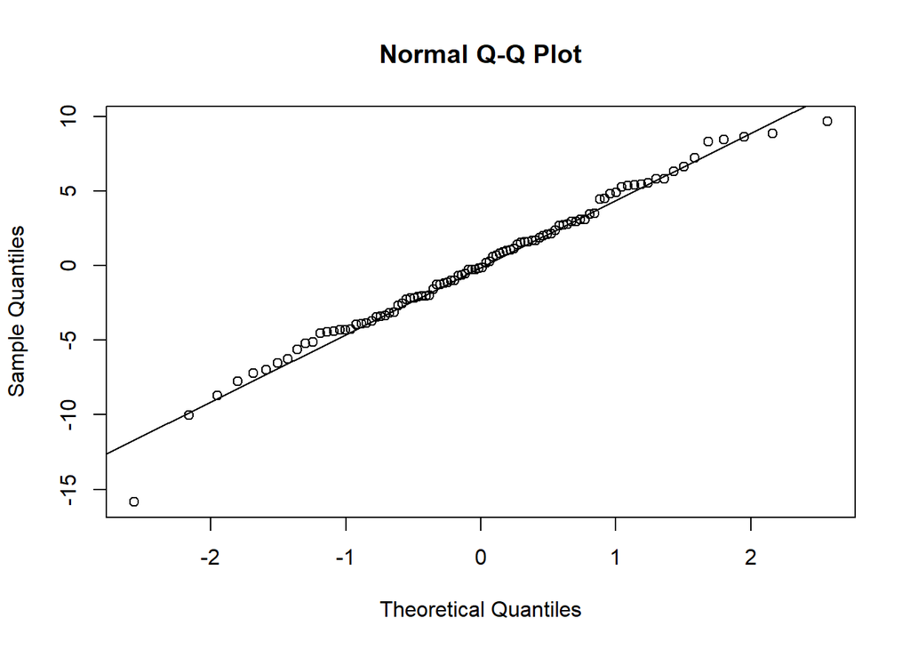

```r
qqnorm(res)
qqline(res)
```

For one simulated data set, we first checked regression based on all parameters, then based on Abdomen circumference only. The R-squared values (0.77/0.67) did not have enough difference to guarantee the more complicated model. For the Abdomen-only model, the residual plot looks random, and the qq plot showed that residuals are normally distributed, which suggests that the regression model was a good fit. The 95% prediction interval included most data points, and the prediction range is 18.91.

Next, we checked the combined data set:

```r
# remove index
df_sample_comb = df_sample_comb[,-1]

# remove density, effectively same as body fat
df_sample_comb = df_sample_comb[,-2]

# all parameters
model1 = lm(BODYFAT~.,data=df_sample_comb)
summary(model1)  #0.77
```

```
##
## Call:
## lm(formula = BODYFAT ~ ., data = df_sample_comb)
##
## Residuals:
##      Min       1Q   Median       3Q      Max
## -12.0084  -2.7955   0.0698   2.7199   8.5858
##
## Coefficients:
##              Estimate Std. Error t value Pr(>|t|)
## (Intercept)  9.516529  22.955120   0.415 0.678643
## AGE          0.032338   0.018775   1.722 0.085646 .
## WEIGHT      -0.009241   0.063395  -0.146 0.884165
## HEIGHT      -0.267581   0.300347  -0.891 0.373431
## ADIPOSITY    0.084907   0.432781   0.196 0.844547
## NECK        -0.577487   0.152117  -3.796 0.000166 ***
## CHEST       -0.045941   0.072307  -0.635 0.525501
## ABDOMEN      0.807252   0.057599  14.015  < 2e-16 ***
## HIP         -0.266484   0.095290  -2.797 0.005374 **
## THIGH        0.153076   0.092550   1.654 0.098794 .
## KNEE         0.004168   0.152253   0.027 0.978174
## ANKLE        0.185899   0.114075   1.630 0.103843
## BICEPS       0.109837   0.111341   0.986 0.324395
## FOREARM      0.152502   0.124011   1.230 0.219402
## WRIST       -0.909563   0.332192  -2.738 0.006412 **
## ---
## Signif. codes:  0 '***' 0.001 '**' 0.01 '*' 0.05 '.' 0.1 ' ' 1
##
## Residual standard error: 3.708 on 475 degrees of freedom
## Multiple R-squared:  0.7677, Adjusted R-squared:  0.7609
## F-statistic: 112.1 on 14 and 475 DF,  p-value: < 2.2e-16
```

```r
# from previous model information, try abdomen only
model4 = lm(BODYFAT~ABDOMEN, data=df_sample_comb)
summary(model4)  #0.69
```

```
##
## Call:
## lm(formula = BODYFAT ~ ABDOMEN, data = df_sample_comb)
##
## Residuals:
##      Min       1Q   Median       3Q      Max
## -18.3396  -3.6943  -0.0205   2.9393   9.2883
##
## Coefficients:
##              Estimate Std. Error t value Pr(>|t|)
## (Intercept) -36.28975    1.68396  -21.55   <2e-16 ***
## ABDOMEN       0.59709    0.01806   33.06   <2e-16 ***
## ---
## Signif. codes:  0 '***' 0.001 '**' 0.01 '*' 0.05 '.' 0.1 ' ' 1
##
## Residual standard error: 4.217 on 488 degrees of freedom
## Multiple R-squared:  0.6914, Adjusted R-squared:  0.6908
## F-statistic:  1093 on 1 and 488 DF,  p-value: < 2.2e-16
```

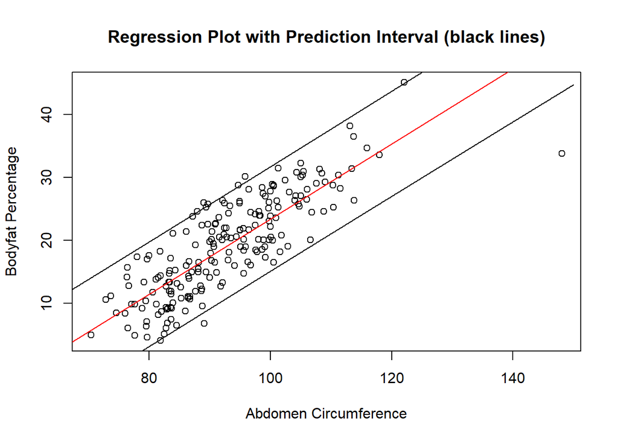

```r
plot(df_sample_comb$ABDOMEN,df_sample_comb$BODYFAT,xlab="Abdomen Circumference",ylab='Bodyfat Percentage',main='Regression Plot with Prediction Interval (black lines)')
abline(model4,col='red')

# create prediction interval
xrange = seq(60,150,0.1)    # checked data range and significant digits from 1970 data set
predicts_ab = matrix(0,nrow=3,ncol=length(xrange))

for (i in 1:length(xrange)){
  predicts_ab[,i] = predict(model4,
                            newdata=data.frame(ABDOMEN=xrange[i]),
                            interval='prediction')
}

lines(xrange,predicts_ab[2,])
lines(xrange,predicts_ab[3,])
```

```r
prediction_range = predicts_ab[3,1] - predicts_ab[2,1]

# prediction range is 16.75, meaning +/- 8.4
prediction_range
```

```
## [1] 16.748
```

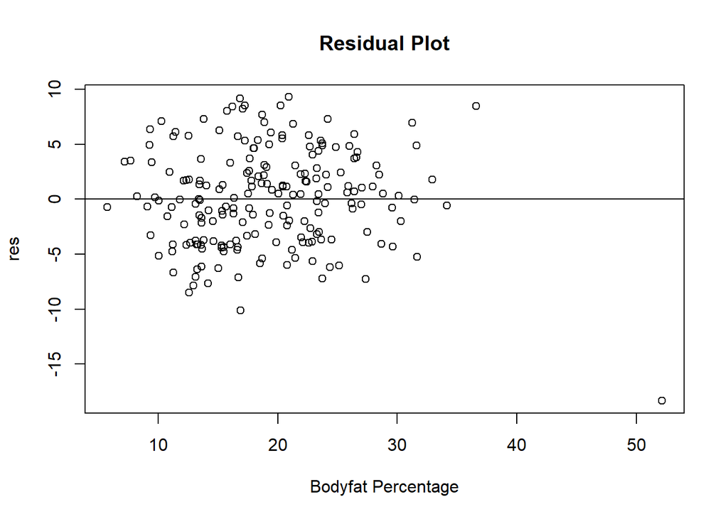

```r
res <- resid(model4)
plot(fitted(model4), res,main='Residual Plot',xlab='Bodyfat Percentage')
abline(0,0)
```

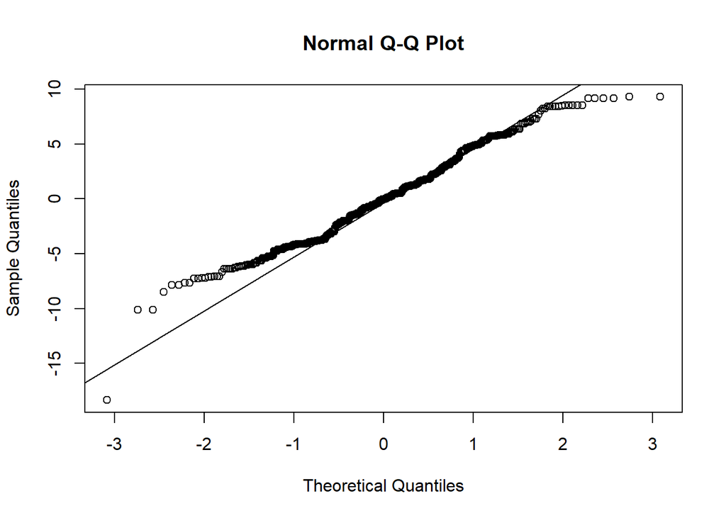

```r
qqnorm(res)
qqline(res)
```

There are two main limitations of this model. First, it was most accurate with age group 20-74 because of the original data set’s limitation. But we believed that predictions for people outside that age group would be accurate to a large extent: the regression model trained on all parameters suggested that age did not significantly influence body fat percentage.

Second, the bootstrapping process counted some data entries repeatedly. For example, every sample in age group 20-24 was counted 5 times by design, since we wanted the sample size to be as large as possible. We considered this a necessary trade-off, since this method brought in much-needed randomness when simulating a new 2022 age distribution.

### b.Weighted Linear Regression

Our second attempt is to implement age distribution close to present by using weights in order to make our prediction model act with present much more robustly. [Age distribution of 2022 comes from [statista](https://www.statista.com/statistics/241488/population-of-the-us-by-sex-and-age/)]

```r
library(tidyverse)
body.fat.ori <- read_csv("https://raw.githubusercontent.com/Star732/stat628/main/Module2/BodyFat.csv")
### remove the 172-th row of data
body.fat <- body.fat.ori[c(1:171, 173:181, 183:dim(body.fat.ori)[1]),]
```

Graph below is the male age distribution in the U.S. of 2022 from official website.

```r
## Official age distribution of 2022
library(ggrepel)
```

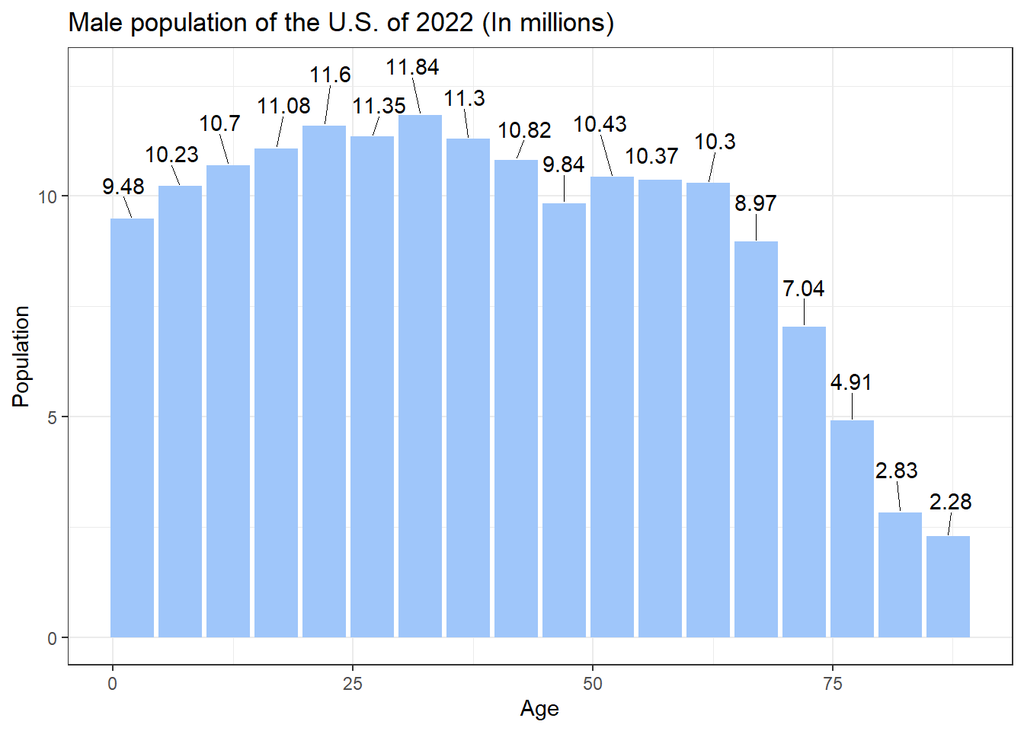

```r
age.pop.2022 <- c(9.48, 10.23, 10.7, 11.08, 11.6, 11.35, 11.84, 11.3, 10.82, 9.84, 10.43, 10.37, 10.3, 8.97, 7.04, 4.91, 2.83, 2.28)
ages <- seq(2, 87, by = 5)
ggplot(data.frame(age = ages, pop = age.pop.2022), aes(x = age, y = pop)) +
  geom_text_repel(aes(label = pop), nudge_y = 0.9, segment.size = 0.2) +
  geom_col(fill = "#9FC6FA") +
  labs(title = "Male population of the U.S. of 2022 (In millions)",
        x = "Age", y = "Population") +
  theme_bw()
```

```r
sample.cnt <- body.fat |>
  group_by(AGE) |>
  summarise(count = n())

used.age <- ages[c(5:(length(ages)-3), length(ages)-1)]

j <- 1
i <- 1
sample.med <- c()
while (i <= dim(sample.cnt)[1]){
  if ((sample.cnt$AGE[i] <= used.age[j]+2) & (sample.cnt$AGE[i] >= used.age[j]-2)){
    sample.med[i] <- used.age[j]
    i <- i+1
  }else{j <- j+1}
}

df.use <- sample.cnt |>
  left_join(data.frame(AGE = sample.cnt$AGE, age.med = sample.med))
new.count <- df.use |>
  group_by(age.med) |>
  summarise(new.count = sum(count)) |>
  pull(new.count)

compare.age <- data.frame(age.med = seq(2,87,by=5), distrib2022 = age.pop.2022, distrib1970 = c(0,0,0,0,10,26,17,21,60,33,26,21,15,12,8,0,1,0))

diff.df <- compare.age |>
  summarise(
    age.med = age.med,
    prob22 = distrib2022/sum(distrib2022),
    prob70 = distrib1970/sum(distrib1970),
    diffs = prob22 / prob70
  )

weights <- diff.df |> pull(diffs)
### cuz we don't have some age intervals in our dataset, so we remove those intervals
used.weight <- weights[c(5:(length(ages)-3), length(ages)-1)]
#used.weight
```

```r
weights.use <- c()

j <- 1
i <- 1
while(i <= dim(sample.cnt)[1]){
  if ((sample.cnt$AGE[i] <= used.age[j]+2) & (sample.cnt$AGE[i] >= used.age[j]-2)){
    wi <- rep(used.weight[j], sample.cnt$count[i])
    #print(wi)
    weights.use <-  append(weights.use, wi)
    i <- i+1
  }else{j <- j+1}
}
## model
l2.wt <- lm(BODYFAT ~ ABDOMEN, data = body.fat, weights = weights.use)
summary(l2.wt)  # 0.7003
```

```
##
## Call:
## lm(formula = BODYFAT ~ ABDOMEN, data = body.fat, weights = weights.use)
##
## Weighted Residuals:
##      Min       1Q   Median       3Q      Max
## -18.3455  -2.4384   0.2128   2.3784  11.3952
##
## Coefficients:
##              Estimate Std. Error t value Pr(>|t|)
## (Intercept) -36.10799    2.31787  -15.58   <2e-16 ***
## ABDOMEN       0.59275    0.02462   24.07   <2e-16 ***
## ---
## Signif. codes:  0 '***' 0.001 '**' 0.01 '*' 0.05 '.' 0.1 ' ' 1
##
## Residual standard error: 3.808 on 248 degrees of freedom
## Multiple R-squared:  0.7003, Adjusted R-squared:  0.6991
## F-statistic: 579.6 on 1 and 248 DF,  p-value: < 2.2e-16
```

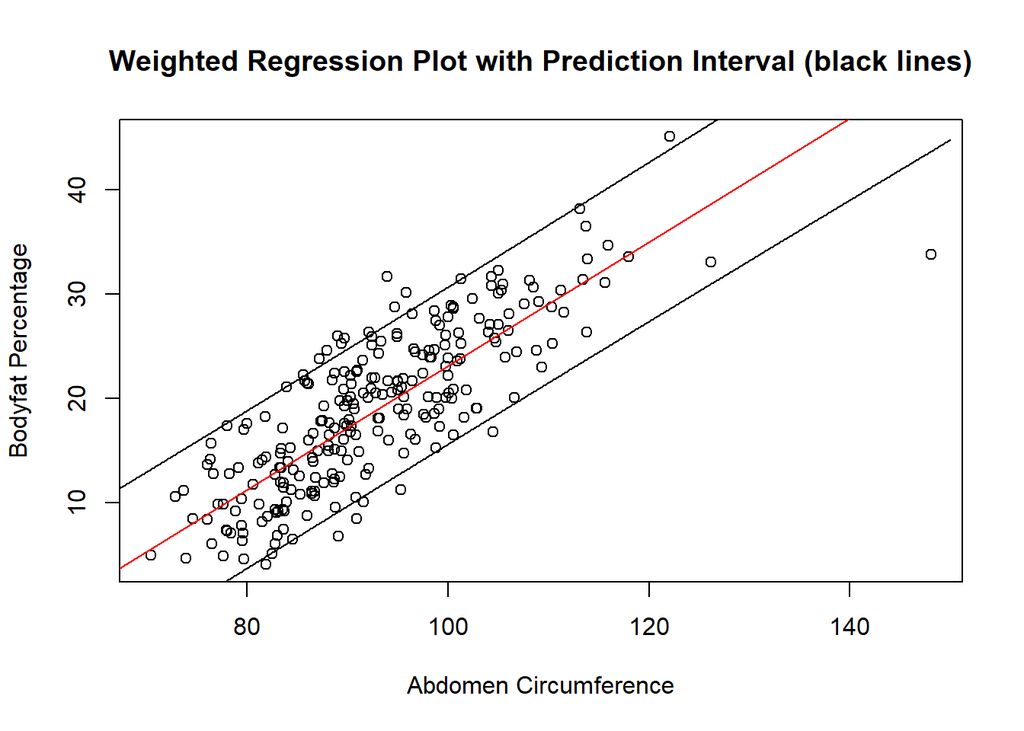

```r
plot(body.fat$ABDOMEN, body.fat$BODYFAT, xlab="Abdomen Circumference", ylab='Bodyfat Percentage', main='Weighted Regression Plot with Prediction Interval (black lines)')
abline(l2.wt, col='red')

# create prediction interval
xrange = seq(60,150,0.1)    # checked data range and significant digits from 1970 data set
predicts_ab = matrix(0,nrow=3,ncol=length(xrange))

for (i in 1:length(xrange)){
  predicts_ab[,i] = suppressWarnings(
    predict(l2.wt,newdata=data.frame(ABDOMEN=xrange[i]),
            interval='prediction'))
}

lines(xrange,predicts_ab[2,])
lines(xrange,predicts_ab[3,])
```

```r
prediction_range = predicts_ab[3,1] - predicts_ab[2,1]

# prediction range is 15.40, meaning +/- 7.70
prediction_range
```

```
## [1] 15.38984
```

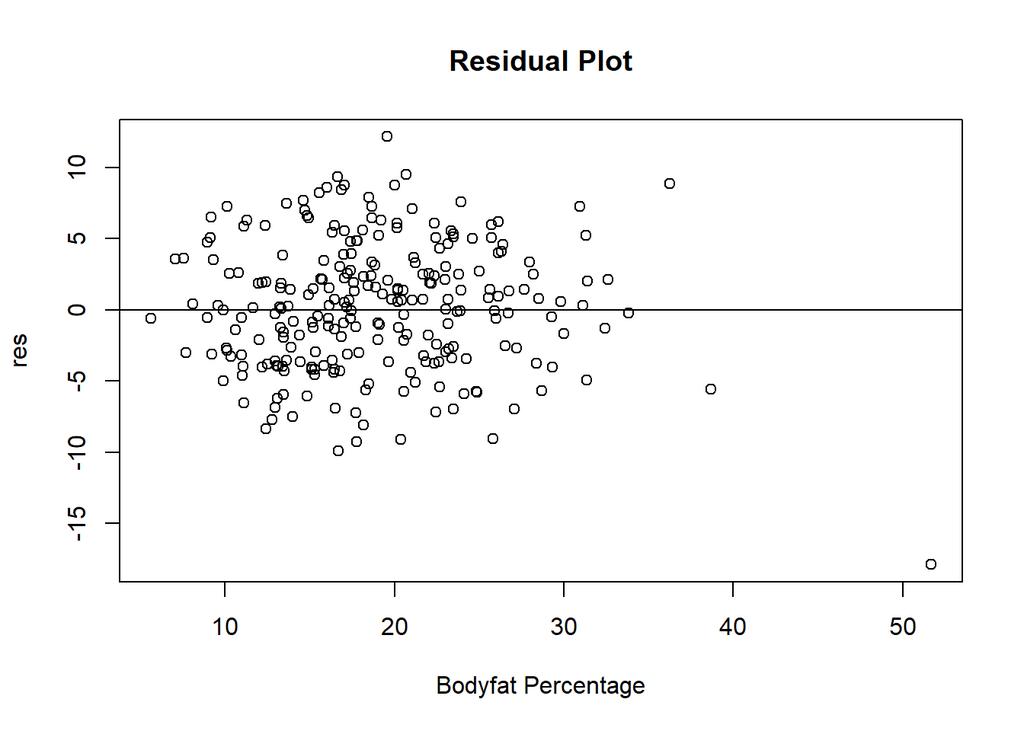

```r
res <- resid(l2.wt)
plot(fitted(l2.wt), res,main='Residual Plot',xlab='Bodyfat Percentage')
abline(0,0)
```

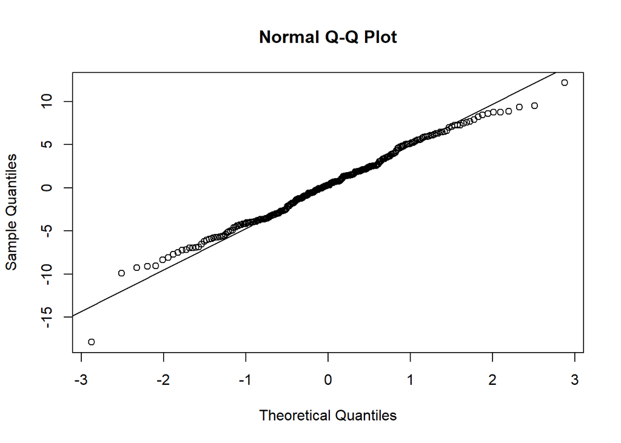

```r
qqnorm(res)
qqline(res)
```

The main problem with weighted regression was that we could not check the model’s performance against a 2022 age distribution. We could only check the performance against 1970 age distribution, as opposed to simulated 2022 age distribution with bootstrapping. However, the bootstrapping process was not significant enough to influence our choice between bootstrapping and weighted regression. The original 1970 data set was too small to produce multiple bootstrap data sets containing vastly different samples. In many age groups, the random selection process was not significant enough.